# Data 621 Homework 3: Code Appendix

Jeff Nieman, Scott Karr, James Topor, Armenoush Aslanian-Persico

Data 621 Homework 3: Boston Crime

# Part 1. Data Exploration

```r
library(bestglm)
library(alr3)
library(car)
library(pROC)
```

```
##        zn             indus             chas              nox
##  Min.   :  0.00   Min.   : 0.460   Min.   :0.00000   Min.   :0.3890
##  1st Qu.:  0.00   1st Qu.: 5.145   1st Qu.:0.00000   1st Qu.:0.4480
##  Median :  0.00   Median : 9.690   Median :0.00000   Median :0.5380
##  Mean   : 11.58   Mean   :11.105   Mean   :0.07082   Mean   :0.5543
##  3rd Qu.: 16.25   3rd Qu.:18.100   3rd Qu.:0.00000   3rd Qu.:0.6240
##  Max.   :100.00   Max.   :27.740   Max.   :1.00000   Max.   :0.8710
##        rm             age              dis              rad
##  Min.   :3.863   Min.   :  2.90   Min.   : 1.130   Min.   : 1.00
##  1st Qu.:5.887   1st Qu.: 43.88   1st Qu.: 2.101   1st Qu.: 4.00
##  Median :6.210   Median : 77.15   Median : 3.191   Median : 5.00
##  Mean   :6.291   Mean   : 68.37   Mean   : 3.796   Mean   : 9.53
##  3rd Qu.:6.630   3rd Qu.: 94.10   3rd Qu.: 5.215   3rd Qu.:24.00
##  Max.   :8.780   Max.   :100.00   Max.   :12.127   Max.   :24.00
##       tax           ptratio         black            lstat
##  Min.   :187.0   Min.   :12.6   Min.   :  0.32   Min.   : 1.730
##  1st Qu.:281.0   1st Qu.:16.9   1st Qu.:375.61   1st Qu.: 7.043
##  Median :334.5   Median :18.9   Median :391.34   Median :11.350
##  Mean   :409.5   Mean   :18.4   Mean   :357.12   Mean   :12.631
##  3rd Qu.:666.0   3rd Qu.:20.2   3rd Qu.:396.24   3rd Qu.:16.930
##  Max.   :711.0   Max.   :22.0   Max.   :396.90   Max.   :37.970
##       medv           target
##  Min.   : 5.00   Min.   :0.0000
##  1st Qu.:17.02   1st Qu.:0.0000
##  Median :21.20   Median :0.0000
##  Mean   :22.59   Mean   :0.4914
##  3rd Qu.:25.00   3rd Qu.:1.0000
##  Max.   :50.00   Max.   :1.0000
```

```
## [1] 466
```

Correlation Matrix of Raw Data

```
##            zn indus  chas   nox    rm   age   dis   rad   tax ptratio
## zn       1.00 -0.54 -0.04 -0.52  0.32 -0.57  0.66 -0.32 -0.32   -0.39
## indus   -0.54  1.00  0.06  0.76 -0.39  0.64 -0.70  0.60  0.73    0.39
## chas    -0.04  0.06  1.00  0.10  0.09  0.08 -0.10 -0.02 -0.05   -0.13
## nox     -0.52  0.76  0.10  1.00 -0.30  0.74 -0.77  0.60  0.65    0.18
## rm       0.32 -0.39  0.09 -0.30  1.00 -0.23  0.20 -0.21 -0.30   -0.36
## age     -0.57  0.64  0.08  0.74 -0.23  1.00 -0.75  0.46  0.51    0.26
## dis      0.66 -0.70 -0.10 -0.77  0.20 -0.75  1.00 -0.49 -0.53   -0.23
## rad     -0.32  0.60 -0.02  0.60 -0.21  0.46 -0.49  1.00  0.91    0.47
## tax     -0.32  0.73 -0.05  0.65 -0.30  0.51 -0.53  0.91  1.00    0.47
## ptratio -0.39  0.39 -0.13  0.18 -0.36  0.26 -0.23  0.47  0.47    1.00
## black    0.18 -0.36  0.04 -0.38  0.13 -0.27  0.29 -0.45 -0.44   -0.18
## lstat   -0.43  0.61 -0.05  0.60 -0.63  0.61 -0.51  0.50  0.56    0.38
## medv     0.38 -0.50  0.16 -0.43  0.71 -0.38  0.26 -0.40 -0.49   -0.52
## target  -0.43  0.60  0.08  0.73 -0.15  0.63 -0.62  0.63  0.61    0.25
##         black lstat  medv target
## zn       0.18 -0.43  0.38  -0.43
## indus   -0.36  0.61 -0.50   0.60
## chas     0.04 -0.05  0.16   0.08
## nox     -0.38  0.60 -0.43   0.73
## rm       0.13 -0.63  0.71  -0.15
## age     -0.27  0.61 -0.38   0.63
## dis      0.29 -0.51  0.26  -0.62
## rad     -0.45  0.50 -0.40   0.63
## tax     -0.44  0.56 -0.49   0.61
## ptratio -0.18  0.38 -0.52   0.25
## black    1.00 -0.35  0.33  -0.35
## lstat   -0.35  1.00 -0.74   0.47
## medv     0.33 -0.74  1.00  -0.27
## target  -0.35  0.47 -0.27   1.00
```

The initial correlation matrix shows some evidence of potential correlation between various variables, with the .91 covariance indicated for the ‘rad’ and ‘tax’ variables being of particular note. However, additional data exploration must be conducted before we can conclude that these initial correlations are offering a valid explanation of the training data.

Boxplots of each independent variable relative to the binary response variable are one way in which we can begin to gain insight into the predictive aspects of the training data:

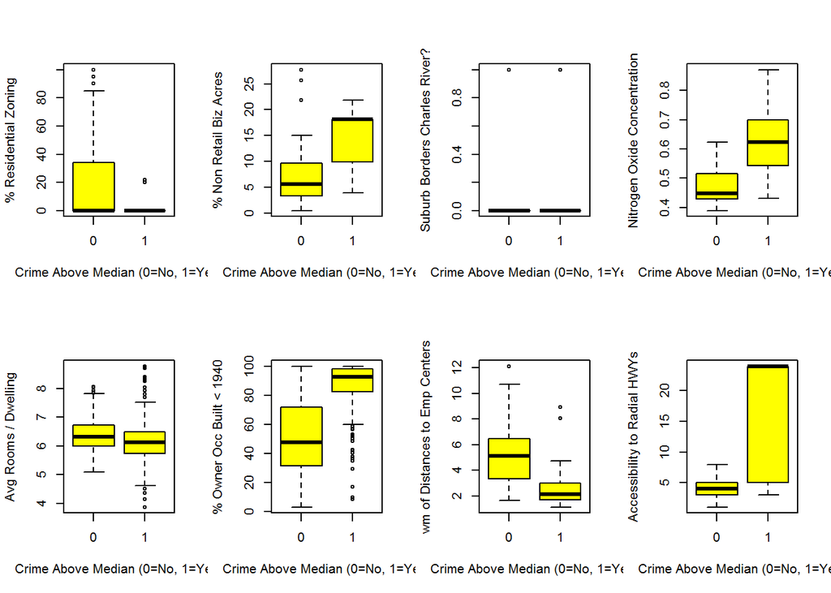

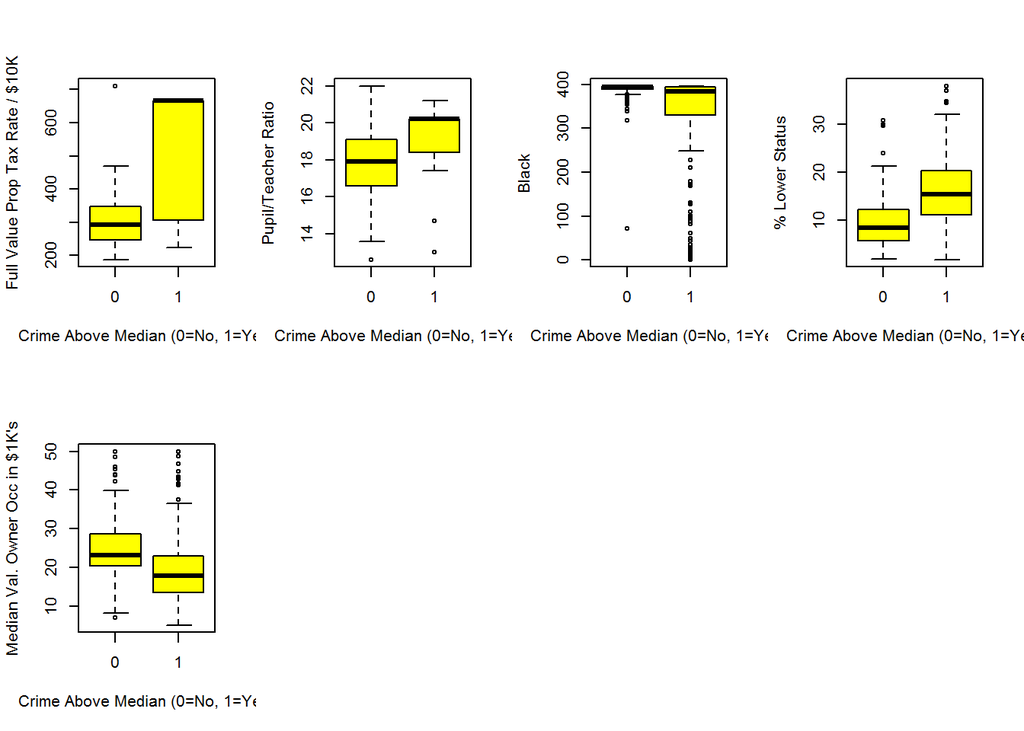

The boxplots show evidence of skew for several of the predictor variables: the ‘zon’, ‘age’, ‘rad’, ‘tax’, ‘ptratio’, and ‘black’ variables each display asymetrical distributions relative to one or both values of the response variable. Such skew may be the result of the presence of outliers or can simply be reflecting the inherent nature of the variable. For example, we would expect the ‘zon’ variable to be skewed due simply to what it characterizes, namely the proportion of residential land zoned for large lots. Obviously, most typical neighborhoods are unlikely to have been zoned to allow for such large lots so we should expect most instances of the variable to be either equal to zero or to be relatively small numbers.

While boxplots are useful for helping to identify potential skew, histograms allow us to more thoroughly examine whether the distribution of a variable is being dominated by a particular set of data values. Histograms for each of the twelve potential predictor variables are provided below.

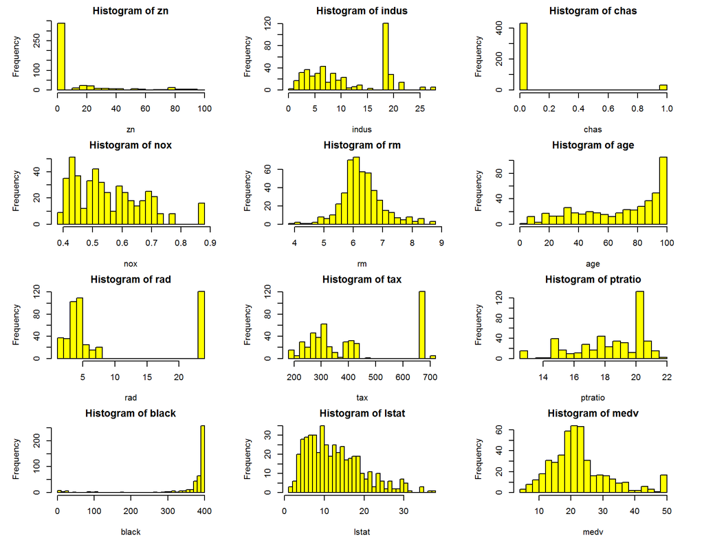

The histograms show that the ‘zon’, ‘chas’, ‘black, ’indus’, ‘rad’, ‘tax’, and ‘ptratio’ variables each have an unusually large number of identical values. Of these, ‘zon’ and ‘chas’ can be explained by their nature: we wouldn’t expect ‘zon’ to have a value greater than zero in most instances and ‘chas’ is a binary categorical variable that can only assume values of either ‘0’ or ‘1’. For the ‘black’ variable it may be the case that many of the neighborhoods represented in the data set have very similar proportions of black residents.

For the ‘indus’, ‘rad’, ‘tax’, and ‘ptratio’ variables, analysis reveals that 121 rows of the training data contain recurring values for each of these variables. The recurring values are summarized below.

| Variable | Value |
| --- | --- |
| indus | 18.1 |
| rad | 24 |
| tax | 666 |
| ptratio | 20.2 |

In fact, further analysis reveals that for the ‘indus’, ‘rad’, and ‘tax’ variables, the values recorded in those 121 rows are distinct relative to the rest of the training data: no other records within the training data set contain those specific recurring values for the indicated variables.

Variable that might be dropped: CHAS, TAX, (NOX / DIS), (RM / MEDV), (AGE / INDUS)

# Part 2 - Data Preparation

# Part 3 - Build Models

Load Training Data

```
## 'data.frame':    466 obs. of  14 variables:
##  $ zn     : int  0 0 0 1 0 0 0 0 0 1 ...
##  $ indus  : num  19.58 19.58 18.1 4.93 2.46 ...
##  $ chas   : int  0 1 0 0 0 0 0 0 0 0 ...
##  $ nox    : num  0.605 0.871 0.74 0.428 0.488 0.52 0.693 0.693 0.515 0.392 ...
##  $ rm     : num  7.93 5.4 6.49 6.39 7.16 ...
##  $ age    : int  1 1 1 0 1 0 1 1 0 0 ...
##  $ dis    : num  2.05 1.32 1.98 7.04 2.7 ...
##  $ rad    : int  5 5 24 6 3 5 24 24 5 1 ...
##  $ tax    : int  403 403 666 300 193 384 666 666 224 315 ...
##  $ ptratio: num  14.7 14.7 20.2 16.6 17.8 20.9 20.2 20.2 20.2 16.4 ...
##  $ black  : num  1.24 1.26 1.25 1.24 1.26 ...
##  $ lstat  : num  3.7 26.82 18.85 5.19 4.82 ...
##  $ medv   : num  50 13.4 15.4 23.7 37.9 26.5 5 7 22.2 20.9 ...
##  $ target : int  1 1 1 0 0 0 1 1 0 0 ...
```

# Model 1: Use the bestglm Function to Build a Model

Use all variables + AIC

**Check for outliers: This MUST be done by hand - the identify function requires that you click on points that are of interest to you so that it can label them. Does not seem possible to use this in a writeup.**

Results say remove rows 14, 18, 159

Now check for outliers again

Results say remove 152, 83, 215

STOP

Now run metrics

Summary Table:

| Metric | Value |
| --- | --- |
| Number of Predictors | 11 |
| AIC | 189.46 |
| Accuracy | 0.9239 |
| Classification Error Rate | 0.0761 |
| Precision | 0.9357 |
| Sensitivity | 0.9067 |
| Specificity | 0.9404 |
| F1 Score | 0.9211 |
| AUC | 0.9235 |

### Bestglm using BIC

```r
# build a model using all potential predictors

X <- hw3.t[, 1:13]
y <- hw3.t[, 14]

xy <- cbind(as.data.frame(X), y)

# method = backward search: yields same result as exhaustive
best.bm <- bestglm(xy, family = binomial(link = "logit"), IC = "BIC", method = "backward")

# show best models - best has lowest AIC (see "Criterion" column)
best.bm$BestModels

# show results for BEST overall model
summary(best.bm$BestModel)
# vif(m1)

# now rebuild by hand so that mmps function can work with it
m.bic <- glm(data = hw3.t, target ~ nox + age + rad + tax, family = binomial(link = "logit"))
summary(m.bic)


# ------------------------
# marginal model plots
mmps(m.bic,layout=c(4,3),key=TRUE)

# Logit model average marginal effects - use it to generate interpretable versions of coefficients
LogitScalar <- mean(dlogis(predict(m.bic, type = "link")))
LogitScalar * coef(m.bic)
# Logit model predicted probabilities - yields likelihood that each eval item is '+'
#
predprob.crime<- round(predict(m.bic, type="response"), 2)
summary(predprob.crime)

# Percent correctly predicted values
# NOTE: Need to create variable 'Y' for this to work - set it to response variable
Y <- hw3.t[,14]

pred.crime <- round(fitted(m.bic))

table(true = Y, pred = pred.crime)


# t.r <- data.frame(table(true = Y, pred = pred.crime))
# t.r

# now use functions built in HW 2 to get required statistics
accuracy(Y, pred.crime)
classif.err.rate(Y, pred.crime)
precision(Y, pred.crime)
sensitivity(Y, pred.crime)
specificity(Y, pred.crime)
F1.Score(Y, pred.crime)

# get AUC
rocCurve <- roc(response= Y, predictor= pred.crime)
auc(rocCurve)
```

[output not shown]

**Check for outliers: This MUST be done by hand - the identify function requires that you click on points that are of interest to you so that it can label them. Does not seem possible to use this in a writeup.**

NO OUTLIERS!!!

Summary Table:

| Metric | Value |
| --- | --- |
| Number of Predictors | 4 |
| AIC | 227.34 |
| Accuracy | 0.8777 |
| Classification Error Rate | 0.1223 |
| Precision | 0.8874 |
| Sensitivity | 0.8603 |
| Specificity | 0.8945 |
| F1 Score | 0.8736 |
| AUC | 0.8774 |

# Model 2: Logit Model Using Backward Selection

```r
#start with CHAS and TAX eliminated
redo <- glm(data=hw3.t, target~.-chas - tax, family=binomial(link="logit"))
summary(redo)
```

```
##
## Call:
## glm(formula = target ~ . - chas - tax, family = binomial(link = "logit"),
##     data = hw3.t)
##
## Deviance Residuals:
##     Min       1Q   Median       3Q      Max
## -2.3238  -0.2257  -0.0184   0.0020   3.6954
##
## Coefficients:
##              Estimate Std. Error z value Pr(>|z|)
## (Intercept) -29.38278    9.10920  -3.226 0.001257 **
## zn1          -2.40227    0.84062  -2.858 0.004267 **
## indus        -0.12937    0.04573  -2.829 0.004671 **
## nox          49.76413    7.87130   6.322 2.58e-10 ***
## rm           -0.54371    0.68080  -0.799 0.424508
## age1          1.36513    0.50068   2.727 0.006400 **
## dis           0.81940    0.21866   3.747 0.000179 ***
## rad           0.57301    0.14289   4.010 6.07e-05 ***
## ptratio       0.25510    0.12065   2.114 0.034479 *
## black        -7.53122    5.44049  -1.384 0.166269
## lstat         0.08170    0.05076   1.610 0.107482
## medv          0.20079    0.06490   3.094 0.001976 **
## ---
## Signif. codes:  0 '***' 0.001 '**' 0.01 '*' 0.05 '.' 0.1 ' ' 1
##
## (Dispersion parameter for binomial family taken to be 1)
##
##     Null deviance: 645.88  on 465  degrees of freedom
## Residual deviance: 195.45  on 454  degrees of freedom
## AIC: 219.45
##
## Number of Fisher Scoring iterations: 9
```

```r
vif(redo)
```

```
##       zn    indus      nox       rm      age      dis      rad  ptratio
## 2.458051 2.617444 4.668796 5.483782 1.959740 4.428175 1.364588 2.075804
##    black    lstat     medv
## 1.050568 2.635865 7.586927
```

```r
#remove rm
redo1 <- glm(data=hw3.t, target~.-chas - tax - rm, family=binomial(link="logit"))
summary(redo1)
```

```
##
## Call:
## glm(formula = target ~ . - chas - tax - rm, family = binomial(link = "logit"),
##     data = hw3.t)
##
## Deviance Residuals:
##     Min       1Q   Median       3Q      Max
## -2.2301  -0.2465  -0.0200   0.0026   3.6926
##
## Coefficients:
##              Estimate Std. Error z value Pr(>|z|)
## (Intercept) -30.90623    8.96234  -3.448 0.000564 ***
## zn1          -2.44648    0.83523  -2.929 0.003399 **
## indus        -0.12989    0.04567  -2.844 0.004456 **
## nox          49.09457    7.76056   6.326 2.51e-10 ***
## age1          1.19155    0.44685   2.667 0.007664 **
## dis           0.79836    0.21499   3.713 0.000204 ***
## rad           0.53939    0.13325   4.048 5.17e-05 ***
## ptratio       0.22147    0.11092   1.997 0.045870 *
## black        -7.39839    5.49195  -1.347 0.177937
## lstat         0.09511    0.04790   1.986 0.047056 *
## medv          0.16225    0.04164   3.896 9.76e-05 ***
## ---
## Signif. codes:  0 '***' 0.001 '**' 0.01 '*' 0.05 '.' 0.1 ' ' 1
##
## (Dispersion parameter for binomial family taken to be 1)
##
##     Null deviance: 645.88  on 465  degrees of freedom
## Residual deviance: 196.09  on 455  degrees of freedom
## AIC: 218.09
##
## Number of Fisher Scoring iterations: 9
```

```r
vif(redo1)
```

```
##       zn    indus      nox      age      dis      rad  ptratio    black
## 2.404000 2.620695 4.525562 1.562843 4.218065 1.199857 1.762695 1.051137
##    lstat     medv
## 2.347105 3.093550
```

```r
#remove black
redo2 <- glm(data=hw3.t, target~.-chas - tax - rm - black, family=binomial(link="logit"))
summary(redo2)
```

```
##
## Call:
## glm(formula = target ~ . - chas - tax - rm - black, family = binomial(link = "logit"),
##     data = hw3.t)
##
## Deviance Residuals:
##     Min       1Q   Median       3Q      Max
## -2.2516  -0.2413  -0.0204   0.0031   3.6903
##
## Coefficients:
##              Estimate Std. Error z value Pr(>|z|)
## (Intercept) -39.63989    6.06071  -6.540 6.13e-11 ***
## zn1          -2.48325    0.82918  -2.995 0.002746 **
## indus        -0.12532    0.04508  -2.780 0.005439 **
## nox          48.80035    7.71002   6.329 2.46e-10 ***
## age1          1.22211    0.44386   2.753 0.005899 **
## dis           0.78972    0.21353   3.698 0.000217 ***
## rad           0.54603    0.13247   4.122 3.76e-05 ***
## ptratio       0.21038    0.10889   1.932 0.053351 .
## lstat         0.09256    0.04786   1.934 0.053104 .
## medv          0.15601    0.04112   3.794 0.000148 ***
## ---
## Signif. codes:  0 '***' 0.001 '**' 0.01 '*' 0.05 '.' 0.1 ' ' 1
##
## (Dispersion parameter for binomial family taken to be 1)
##
##     Null deviance: 645.88  on 465  degrees of freedom
## Residual deviance: 198.40  on 456  degrees of freedom
## AIC: 218.4
##
## Number of Fisher Scoring iterations: 9
```

```r
vif(redo2)
```

```
##       zn    indus      nox      age      dis      rad  ptratio    lstat
## 2.377473 2.575499 4.451908 1.565612 4.121229 1.199413 1.742364 2.345083
##     medv
## 3.062759
```

```r
#remove ptratio
redo3 <- glm(data=hw3.t, target~.-chas - tax - rm - black - ptratio, family=binomial(link="logit"))
summary(redo3)
```

```
##
## Call:
## glm(formula = target ~ . - chas - tax - rm - black - ptratio,
##     family = binomial(link = "logit"), data = hw3.t)
##
## Deviance Residuals:
##     Min       1Q   Median       3Q      Max
## -2.1506  -0.2322  -0.0211   0.0050   3.7590
##
## Coefficients:
##              Estimate Std. Error z value Pr(>|z|)
## (Intercept) -34.26432    5.16106  -6.639 3.16e-11 ***
## zn1          -3.06008    0.80363  -3.808  0.00014 ***
## indus        -0.11770    0.04453  -2.643  0.00822 **
## nox          47.19316    7.55639   6.245 4.23e-10 ***
## age1          1.20526    0.43953   2.742  0.00610 **
## dis           0.83789    0.21349   3.925 8.68e-05 ***
## rad           0.50366    0.12831   3.925 8.66e-05 ***
## lstat         0.08995    0.04677   1.923  0.05445 .
## medv          0.13226    0.03864   3.423  0.00062 ***
## ---
## Signif. codes:  0 '***' 0.001 '**' 0.01 '*' 0.05 '.' 0.1 ' ' 1
##
## (Dispersion parameter for binomial family taken to be 1)
##
##     Null deviance: 645.88  on 465  degrees of freedom
## Residual deviance: 202.17  on 457  degrees of freedom
## AIC: 220.17
##
## Number of Fisher Scoring iterations: 9
```

```r
vif(redo3)
```

```
##       zn    indus      nox      age      dis      rad    lstat     medv
## 2.116670 2.639962 4.443026 1.564002 4.117494 1.146209 2.379362 2.776842
```

```r
#remove lstat
redo4 <- glm(data=hw3.t, target~.-chas - tax - rm - black - ptratio - lstat, family=binomial(link="logit"))
summary(redo4)
```

```
##
## Call:
## glm(formula = target ~ . - chas - tax - rm - black - ptratio -
##     lstat, family = binomial(link = "logit"), data = hw3.t)
##
## Deviance Residuals:
##     Min       1Q   Median       3Q      Max
## -1.8643  -0.2428  -0.0310   0.0060   3.6744
##
## Coefficients:
##              Estimate Std. Error z value Pr(>|z|)
## (Intercept) -31.02452    4.65124  -6.670 2.56e-11 ***
## zn1          -2.63156    0.73554  -3.578 0.000347 ***
## indus        -0.10369    0.04353  -2.382 0.017219 *
## nox          45.12985    7.27072   6.207 5.40e-10 ***
## age1          1.39407    0.42773   3.259 0.001117 **
## dis           0.74725    0.20310   3.679 0.000234 ***
## rad           0.50907    0.12521   4.066 4.79e-05 ***
## medv          0.08775    0.02970   2.955 0.003128 **
## ---
## Signif. codes:  0 '***' 0.001 '**' 0.01 '*' 0.05 '.' 0.1 ' ' 1
##
## (Dispersion parameter for binomial family taken to be 1)
##
##     Null deviance: 645.88  on 465  degrees of freedom
## Residual deviance: 205.87  on 458  degrees of freedom
## AIC: 221.87
##
## Number of Fisher Scoring iterations: 8
```

```r
vif(redo4)
```

```
##       zn    indus      nox      age      dis      rad     medv
## 1.923310 2.522150 4.217279 1.507917 3.934578 1.163008 1.683635
```

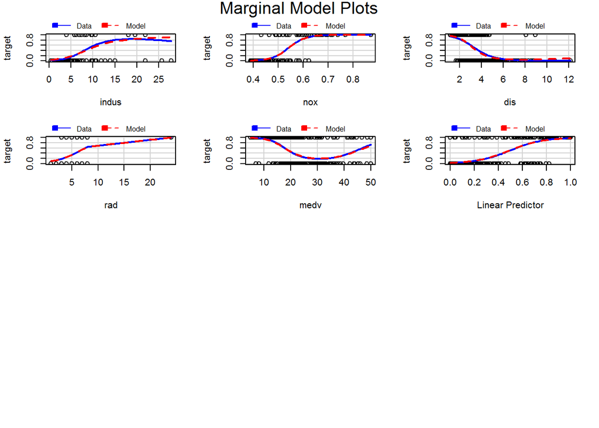

```r
redo.fit <- round(fitted(redo4))

# ------------------------
# marginal model plots
mmps(redo4,layout=c(4,3),key=TRUE)
```

```r
# ----------------------------
# Coefficient Interpretation

# Logit model average marginal effects - use it to generate interpretable versions of coefficients
LogitScalar.sub <- mean(dlogis(predict(redo4, type = "link")))
LogitScalar.sub * coef(redo4)
```

```
##  (Intercept)          zn1        indus          nox         age1
## -2.195496212 -0.186226051 -0.007337724  3.193680201  0.098653123
##          dis          rad         medv
##  0.052880236  0.036025387  0.006209541
```

```r
Y <- hw3.t[,14]
table(true = Y, pred = redo.fit)
```

```
##     pred
## true   0   1
##    0 218  19
##    1  22 207
```

```r
# t.r <- data.frame(table(true = Y, pred = pred.crime))
# t.r

# now use functions built in HW 2 to get required statistics
accuracy(Y, redo.fit)
```

```
## [1] 0.9120172
```

```r
classif.err.rate(Y, redo.fit)
```

```
## [1] 0.08798283
```

```r
precision(Y, redo.fit)
```

```
## [1] 0.9159292
```

```r
sensitivity(Y, redo.fit)
```

```
## [1] 0.9039301
```

```r
specificity(Y, redo.fit)
```

```
## [1] 0.9198312
```

```r
F1.Score(Y, redo.fit)
```

```
## [1] 0.9098901
```

```r
#look at misses
hw3t.4 <- hw3.t
hw3t.4$predict <- fitted(redo4)
miss.4 <- subset(hw3t.4[which(hw3.t$target != redo.fit),])

#AUC
rocCurve <- roc(response= Y, predictor= redo.fit)
auc(rocCurve)
```

```
## Area under the curve: 0.9119
```

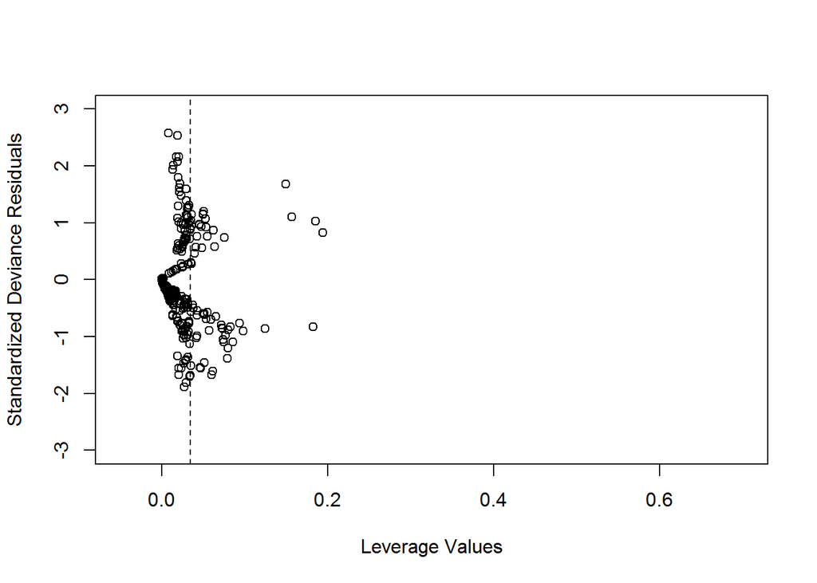

```
## integer(0)
```

```r
#See Figure 8.13 on page 291
par(mfrow=c(1,1))
hvalues <- influence(redo4)$hat
stanresDeviance <- residuals(redo4)/sqrt(1-hvalues)

plot(hvalues,stanresDeviance,ylab="Standardized Deviance Residuals",
     xlab="Leverage Values",ylim=c(-3,3),xlim=c(-0.05,0.7))

# NOTE: the '12' indicated here is found by adding 1 to the number of predictor variables
# used in the final model
abline(v=2* 8 / nrow(hw3.t),lty=2)

hw3.names <- as.character(seq(1:nrow(hw3.t)))

# need to click on potential outliers using the mouse and then click "finish" in the plot window
identify(hvalues, stanresDeviance, labels = hw3.names, cex=0.75)
```

```r
#Remove outliers #396, 18, 85, 218, 14
hw3.o <- hw3.t[-c(14,18,85,218, 396),]
redo4.1 <- glm(data=hw3.o, target~.-chas - tax - rm - black - ptratio - lstat, family=binomial(link="logit"))
summary(redo4)
```

```
##
## Call:
## glm(formula = target ~ . - chas - tax - rm - black - ptratio -
##     lstat, family = binomial(link = "logit"), data = hw3.t)
##
## Deviance Residuals:
##     Min       1Q   Median       3Q      Max
## -1.8643  -0.2428  -0.0310   0.0060   3.6744
##
## Coefficients:
##              Estimate Std. Error z value Pr(>|z|)
## (Intercept) -31.02452    4.65124  -6.670 2.56e-11 ***
## zn1          -2.63156    0.73554  -3.578 0.000347 ***
## indus        -0.10369    0.04353  -2.382 0.017219 *
## nox          45.12985    7.27072   6.207 5.40e-10 ***
## age1          1.39407    0.42773   3.259 0.001117 **
## dis           0.74725    0.20310   3.679 0.000234 ***
## rad           0.50907    0.12521   4.066 4.79e-05 ***
## medv          0.08775    0.02970   2.955 0.003128 **
## ---
## Signif. codes:  0 '***' 0.001 '**' 0.01 '*' 0.05 '.' 0.1 ' ' 1
##
## (Dispersion parameter for binomial family taken to be 1)
##
##     Null deviance: 645.88  on 465  degrees of freedom
## Residual deviance: 205.87  on 458  degrees of freedom
## AIC: 221.87
##
## Number of Fisher Scoring iterations: 8
```

```r
prediction <- round(predict(redo4.1, newdata=hw3.t, type="response"))

table(true = Y, pred = prediction)
```

```
##     pred
## true   0   1
##    0 218  19
##    1  21 208
```

```r
accuracy(Y, prediction)
```

```
## [1] 0.9141631
```

```r
classif.err.rate(Y, prediction)
```

```
## [1] 0.08583691
```

```r
precision(Y, prediction)
```

```
## [1] 0.9162996
```

```r
sensitivity(Y, prediction)
```

```
## [1] 0.9082969
```

```r
specificity(Y, prediction)
```

```
## [1] 0.9198312
```

```r
F1.Score(Y, prediction)
```

```
## [1] 0.9122807
```

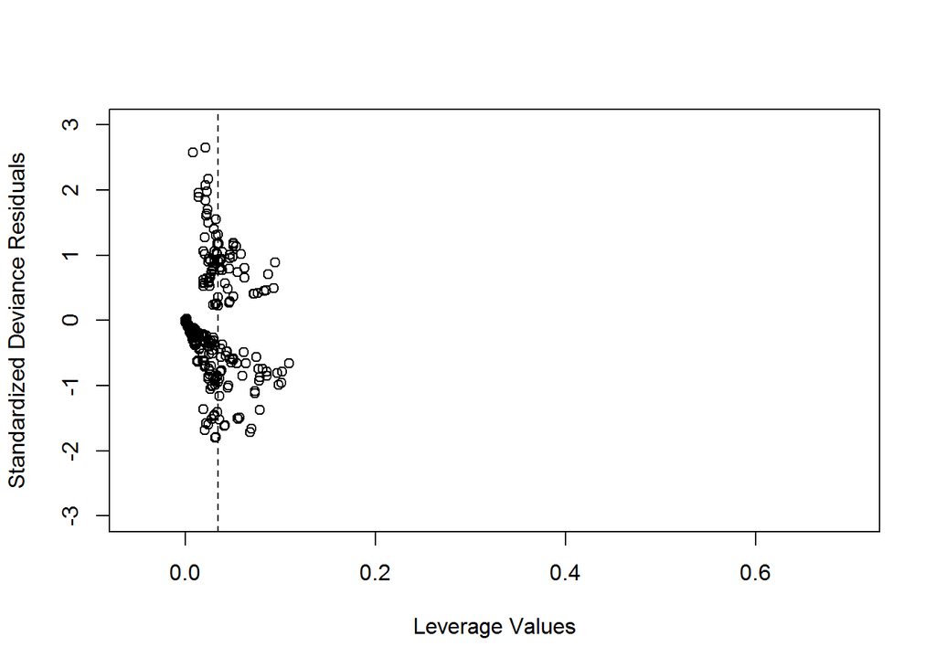

```r
par(mfrow=c(1,1))
hvalues <- influence(redo4.1)$hat
stanresDeviance <- residuals(redo4.1)/sqrt(1-hvalues)

plot(hvalues,stanresDeviance,ylab="Standardized Deviance Residuals",
     xlab="Leverage Values",ylim=c(-3,3),xlim=c(-0.05,0.7))

# NOTE: the '12' indicated here is found by adding 1 to the number of predictor variables
# used in the final model
abline(v=2* 8 / nrow(hw3.t),lty=2)
```

```r
hw3.names <- as.character(seq(1:nrow(hw3.t)))

#no outliers

#AUC
rocCurve <- roc(response= Y, predictor= prediction)
auc(rocCurve)
```

```
## Area under the curve: 0.9141
```

# Model 3: Probit Model Using Backward Selection

```r
#probit - again starting with no TAX and CHAS
pmod <- glm(data=hw3.t, target~. - tax- chas, family=binomial(link="probit"))
summary(pmod)
```

```
##
## Call:
## glm(formula = target ~ . - tax - chas, family = binomial(link = "probit"),
##     data = hw3.t)
##
## Deviance Residuals:
##     Min       1Q   Median       3Q      Max
## -2.2256  -0.2445  -0.0032   0.0000   3.9212
##
## Coefficients:
##              Estimate Std. Error z value Pr(>|z|)
## (Intercept) -14.77129    5.00943  -2.949  0.00319 **
## zn1          -0.95557    0.42190  -2.265  0.02352 *
## indus        -0.06550    0.02488  -2.632  0.00849 **
## nox          25.58271    4.02313   6.359 2.03e-10 ***
## rm           -0.31252    0.37050  -0.844  0.39894
## age1          0.71386    0.27627   2.584  0.00977 **
## dis           0.37495    0.11551   3.246  0.00117 **
## rad           0.30129    0.07474   4.031 5.55e-05 ***
## ptratio       0.14916    0.06591   2.263  0.02363 *
## black        -4.17851    3.10279  -1.347  0.17808
## lstat         0.04098    0.02819   1.454  0.14604
## medv          0.10395    0.03389   3.067  0.00216 **
## ---
## Signif. codes:  0 '***' 0.001 '**' 0.01 '*' 0.05 '.' 0.1 ' ' 1
##
## (Dispersion parameter for binomial family taken to be 1)
##
##     Null deviance: 645.88  on 465  degrees of freedom
## Residual deviance: 199.77  on 454  degrees of freedom
## AIC: 223.77
##
## Number of Fisher Scoring iterations: 12
```

```r
vif(pmod)
```

```
##       zn    indus      nox       rm      age      dis      rad  ptratio
## 2.365415 2.540325 4.454924 5.483796 1.902328 4.400903 1.274948 1.954070
##    black    lstat     medv
## 1.049779 2.618295 7.023299
```

```r
#get rid of rm
pmod1 <- glm(data=hw3.t, target~. - tax- chas - rm, family=binomial(link="probit"))
summary(pmod1)
```

```
##
## Call:
## glm(formula = target ~ . - tax - chas - rm, family = binomial(link = "probit"),
##     data = hw3.t)
##
## Deviance Residuals:
##     Min       1Q   Median       3Q      Max
## -2.1317  -0.2585  -0.0037   0.0000   3.9216
##
## Coefficients:
##              Estimate Std. Error z value Pr(>|z|)
## (Intercept) -15.77148    4.87705  -3.234 0.001221 **
## zn1          -0.98509    0.41504  -2.373 0.017621 *
## indus        -0.06528    0.02481  -2.632 0.008494 **
## nox          25.22038    3.95156   6.382 1.74e-10 ***
## age1          0.60979    0.24929   2.446 0.014442 *
## dis           0.36576    0.11337   3.226 0.001255 **
## rad           0.28576    0.07089   4.031 5.56e-05 ***
## ptratio       0.13144    0.06146   2.139 0.032463 *
## black        -4.08946    3.11494  -1.313 0.189232
## lstat         0.05020    0.02622   1.914 0.055578 .
## medv          0.08268    0.02182   3.789 0.000151 ***
## ---
## Signif. codes:  0 '***' 0.001 '**' 0.01 '*' 0.05 '.' 0.1 ' ' 1
##
## (Dispersion parameter for binomial family taken to be 1)
##
##     Null deviance: 645.88  on 465  degrees of freedom
## Residual deviance: 200.46  on 455  degrees of freedom
## AIC: 222.46
##
## Number of Fisher Scoring iterations: 12
```

```r
vif(pmod1)
```

```
##       zn    indus      nox      age      dis      rad  ptratio    black
## 2.286815 2.542446 4.328321 1.557061 4.204075 1.165641 1.708739 1.050144
##    lstat     medv
## 2.283869 2.931991
```

```r
#get rid of black
pmod2 <- glm(data=hw3.t, target~. - tax- chas - rm - black, family=binomial(link="probit"))
summary(pmod2)
```

```
##
## Call:
## glm(formula = target ~ . - tax - chas - rm - black, family = binomial(link = "probit"),
##     data = hw3.t)
##
## Deviance Residuals:
##     Min       1Q   Median       3Q      Max
## -2.1501  -0.2526  -0.0038   0.0000   3.9137
##
## Coefficients:
##              Estimate Std. Error z value Pr(>|z|)
## (Intercept) -20.59379    3.10278  -6.637 3.20e-11 ***
## zn1          -0.99820    0.41261  -2.419 0.015554 *
## indus        -0.06285    0.02456  -2.559 0.010487 *
## nox          24.98786    3.92633   6.364 1.96e-10 ***
## age1          0.63248    0.24792   2.551 0.010738 *
## dis           0.35924    0.11291   3.182 0.001465 **
## rad           0.29002    0.07060   4.108 3.99e-05 ***
## ptratio       0.12680    0.06079   2.086 0.036980 *
## lstat         0.04866    0.02620   1.857 0.063260 .
## medv          0.07944    0.02159   3.680 0.000234 ***
## ---
## Signif. codes:  0 '***' 0.001 '**' 0.01 '*' 0.05 '.' 0.1 ' ' 1
##
## (Dispersion parameter for binomial family taken to be 1)
##
##     Null deviance: 645.88  on 465  degrees of freedom
## Residual deviance: 202.72  on 456  degrees of freedom
## AIC: 222.72
##
## Number of Fisher Scoring iterations: 10
```

```r
vif(pmod2)
```

```
##       zn    indus      nox      age      dis      rad  ptratio    lstat
## 2.258185 2.500816 4.257708 1.553641 4.121265 1.165747 1.691050 2.279136
##     medv
## 2.892678
```

```r
#get rid of lstat
pmod3 <- glm(data=hw3.t, target~. - tax- chas - rm - black - lstat, family=binomial(link="probit"))
summary(pmod3)
```

```
##
## Call:
## glm(formula = target ~ . - tax - chas - rm - black - lstat, family = binomial(link = "probit"),
##     data = hw3.t)
##
## Deviance Residuals:
##     Min       1Q   Median       3Q      Max
## -1.8598  -0.2660  -0.0062   0.0000   3.8284
##
## Coefficients:
##              Estimate Std. Error z value Pr(>|z|)
## (Intercept) -18.70441    2.86028  -6.539 6.18e-11 ***
## zn1          -0.86185    0.38952  -2.213  0.02692 *
## indus        -0.05485    0.02390  -2.295  0.02175 *
## nox          23.81223    3.77190   6.313 2.74e-10 ***
## age1          0.73167    0.24044   3.043  0.00234 **
## dis           0.31276    0.10758   2.907  0.00365 **
## rad           0.29011    0.06889   4.211 2.54e-05 ***
## ptratio       0.12089    0.06043   2.001  0.04544 *
## medv          0.05602    0.01706   3.283  0.00103 **
## ---
## Signif. codes:  0 '***' 0.001 '**' 0.01 '*' 0.05 '.' 0.1 ' ' 1
##
## (Dispersion parameter for binomial family taken to be 1)
##
##     Null deviance: 645.88  on 465  degrees of freedom
## Residual deviance: 206.46  on 457  degrees of freedom
## AIC: 224.46
##
## Number of Fisher Scoring iterations: 10
```

```r
vif(pmod3)
```

```
##       zn    indus      nox      age      dis      rad  ptratio     medv
## 2.152354 2.403601 4.112197 1.488618 3.925404 1.167530 1.703963 1.859259
```

```r
pmod.fit <- round(fitted(pmod3))

# ------------------------
# marginal model plots


# ----------------------------
# Coefficient Interpretation

# Logit model average marginal effects - use it to generate interpretable versions of coefficients
LogitScalar.sub <- mean(dlogis(predict(pmod3, type = "link")))
LogitScalar.sub * coef(pmod3)
```

```
##  (Intercept)          zn1        indus          nox         age1
## -1.993004590 -0.091832408 -0.005844793  2.537255851  0.077961626
##          dis          rad      ptratio         medv
##  0.033325850  0.030912388  0.012881636  0.005968772
```

```r
table(true = Y, pred = pmod.fit)
```

```
##     pred
## true   0   1
##    0 218  19
##    1  21 208
```

```r
# t.r <- data.frame(table(true = Y, pred = pred.crime))
# t.r

# now use functions built in HW 2 to get required statistics
accuracy(Y, pmod.fit)
```

```
## [1] 0.9141631
```

```r
classif.err.rate(Y, pmod.fit)
```

```
## [1] 0.08583691
```

```r
precision(Y, pmod.fit)
```

```
## [1] 0.9162996
```

```r
sensitivity(Y, pmod.fit)
```

```
## [1] 0.9082969
```

```r
specificity(Y, pmod.fit)
```

```
## [1] 0.9198312
```

```r
F1.Score(Y, pmod.fit)
```

```
## [1] 0.9122807
```

```r
#auc
rocCurve <- roc(response= Y, predictor= pmod.fit)
auc(rocCurve)
```

```
## Area under the curve: 0.9141
```

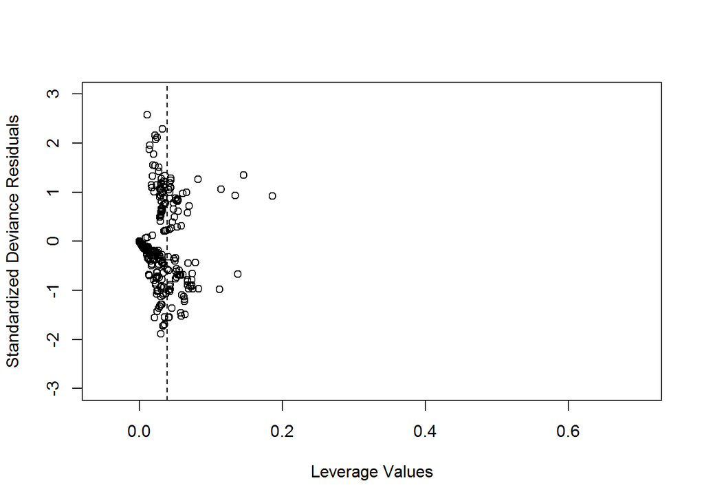

```
## integer(0)
```

```r
#look for outliers

#See Figure 8.13 on page 291
par(mfrow=c(1,1))
hvalues <- influence(pmod3)$hat
stanresDeviance <- residuals(pmod3)/sqrt(1-hvalues)

plot(hvalues,stanresDeviance,ylab="Standardized Deviance Residuals",
     xlab="Leverage Values",ylim=c(-3,3),xlim=c(-0.05,0.7))

# NOTE: the '12' indicated here is found by adding 1 to the number of predictor variables
# used in the final model
abline(v=2* 9 / nrow(hw3.t),lty=2)

hw3.names <- as.character(seq(1:nrow(hw3.t)))

# need to click on potential outliers using the mouse and then click "finish" in the plot window
identify(hvalues, stanresDeviance, labels = hw3.names, cex=0.75)
```

```r
#Remove outliers #396, 18, 85, 14
hw3.o.p <- hw3.t[-c(14,18,85, 396),]
pmod3.1 <- glm(data=hw3.o.p, target~. - tax- chas - rm - black - lstat, family=binomial(link="probit"))
summary(pmod3.1)
```

```
##
## Call:
## glm(formula = target ~ . - tax - chas - rm - black - lstat, family = binomial(link = "probit"),
##     data = hw3.o.p)
##
## Deviance Residuals:
##     Min       1Q   Median       3Q      Max
## -1.8022  -0.2647  -0.0065   0.0000   3.9000
##
## Coefficients:
##              Estimate Std. Error z value Pr(>|z|)
## (Intercept) -17.93752    2.87908  -6.230 4.66e-10 ***
## zn1          -1.00492    0.41051  -2.448  0.01437 *
## indus        -0.05227    0.02406  -2.173  0.02981 *
## nox          22.83626    3.77716   6.046 1.49e-09 ***
## age1          0.75831    0.24499   3.095  0.00197 **
## dis           0.31715    0.11789   2.690  0.00714 **
## rad           0.28931    0.06986   4.141 3.45e-05 ***
## ptratio       0.11240    0.06143   1.830  0.06726 .
## medv          0.05001    0.01789   2.795  0.00519 **
## ---
## Signif. codes:  0 '***' 0.001 '**' 0.01 '*' 0.05 '.' 0.1 ' ' 1
##
## (Dispersion parameter for binomial family taken to be 1)
##
##     Null deviance: 640.25  on 461  degrees of freedom
## Residual deviance: 202.64  on 453  degrees of freedom
## AIC: 220.64
##
## Number of Fisher Scoring iterations: 10
```

```r
#remove ptratio
pmod3.2 <- glm(data=hw3.o.p, target~. - tax- chas - rm - black - lstat -ptratio, family=binomial(link="probit"))
summary(pmod3.2)
```

```
##
## Call:
## glm(formula = target ~ . - tax - chas - rm - black - lstat -
##     ptratio, family = binomial(link = "probit"), data = hw3.o.p)
##
## Deviance Residuals:
##     Min       1Q   Median       3Q      Max
## -1.7329  -0.2490  -0.0123   0.0000   3.9778
##
## Coefficients:
##              Estimate Std. Error z value Pr(>|z|)
## (Intercept) -15.17084    2.35792  -6.434 1.24e-10 ***
## zn1          -1.23712    0.39527  -3.130  0.00175 **
## indus        -0.04966    0.02380  -2.087  0.03693 *
## nox          22.24095    3.71283   5.990 2.09e-09 ***
## age1          0.72982    0.24167   3.020  0.00253 **
## dis           0.33442    0.11863   2.819  0.00482 **
## rad           0.27352    0.06893   3.968 7.24e-05 ***
## medv          0.03579    0.01599   2.238  0.02522 *
## ---
## Signif. codes:  0 '***' 0.001 '**' 0.01 '*' 0.05 '.' 0.1 ' ' 1
##
## (Dispersion parameter for binomial family taken to be 1)
##
##     Null deviance: 640.25  on 461  degrees of freedom
## Residual deviance: 205.77  on 454  degrees of freedom
## AIC: 221.77
##
## Number of Fisher Scoring iterations: 10
```

```r
prediction.p <- round(predict(pmod3.2, newdata=hw3.t, type="response"))

table(true = Y, pred = prediction.p)
```

```
##     pred
## true   0   1
##    0 218  19
##    1  22 207
```

```r
accuracy(Y, prediction.p)
```

```
## [1] 0.9120172
```

```r
classif.err.rate(Y, prediction.p)
```

```
## [1] 0.08798283
```

```r
precision(Y, prediction.p)
```

```
## [1] 0.9159292
```

```r
sensitivity(Y, prediction.p)
```

```
## [1] 0.9039301
```

```r
specificity(Y, prediction.p)
```

```
## [1] 0.9198312
```

```r
F1.Score(Y, prediction.p)
```

```
## [1] 0.9098901
```

```r
#auc
rocCurve <- roc(response= Y, predictor= prediction.p)
auc(rocCurve)
```

```
## Area under the curve: 0.9119
```

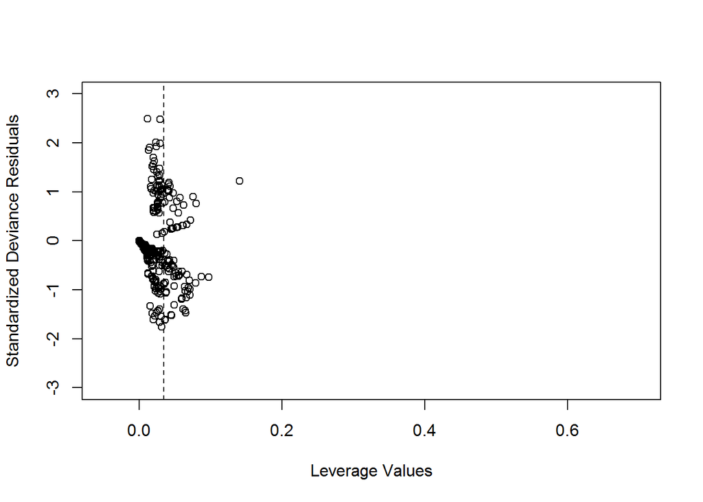

```r
#check for outliers
par(mfrow=c(1,1))
hvalues <- influence(pmod3.2)$hat
stanresDeviance <- residuals(pmod3.2)/sqrt(1-hvalues)

plot(hvalues,stanresDeviance,ylab="Standardized Deviance Residuals",
     xlab="Leverage Values",ylim=c(-3,3),xlim=c(-0.05,0.7))

# NOTE: the '8' indicated here is found by adding 1 to the number of predictor variables
# used in the final model
abline(v=2* 8 / nrow(hw3.t),lty=2)
```

```r
#SCott's model updated


# BUILD MODEL
```

**Check for outliers: This MUST be done by hand - the identify function requires that you click on points that are of interest to you so that it can label them. Does not seem possible to use this in a writeup.**

There are no outliers.

# Model 4: Forward Selection + AIC

```r
library(bestglm)
library(alr3)
library(car)
library(pROC)
```

Load Training Data

```
## 'data.frame':    466 obs. of  14 variables:
##  $ zn     : int  0 0 0 1 0 0 0 0 0 1 ...
##  $ indus  : num  19.58 19.58 18.1 4.93 2.46 ...
##  $ chas   : int  0 1 0 0 0 0 0 0 0 0 ...
##  $ nox    : num  0.605 0.871 0.74 0.428 0.488 0.52 0.693 0.693 0.515 0.392 ...
##  $ rm     : num  7.93 5.4 6.49 6.39 7.16 ...
##  $ age    : int  1 1 1 0 1 0 1 1 0 0 ...
##  $ dis    : num  2.05 1.32 1.98 7.04 2.7 ...
##  $ rad    : int  5 5 24 6 3 5 24 24 5 1 ...
##  $ tax    : int  403 403 666 300 193 384 666 666 224 315 ...
##  $ ptratio: num  14.7 14.7 20.2 16.6 17.8 20.9 20.2 20.2 20.2 16.4 ...
##  $ black  : num  1.24 1.26 1.25 1.24 1.26 ...
##  $ lstat  : num  3.7 26.82 18.85 5.19 4.82 ...
##  $ medv   : num  50 13.4 15.4 23.7 37.9 26.5 5 7 22.2 20.9 ...
##  $ target : int  1 1 1 0 0 0 1 1 0 0 ...
```

## Use the bestglm Function to Build a Model

Forward Selection + AIC

- This table shows variables with high correlation where only one per model should be chosen

[output not shown]

BUILD MODEL

```
##
## Call:
## glm(formula = target ~ nox, family = binomial(link = "logit"),
##     data = hw3.t)
##
## Deviance Residuals:
##     Min       1Q   Median       3Q      Max
## -2.2456  -0.3759  -0.1675   0.3707   2.5576
##
## Coefficients:
##             Estimate Std. Error z value Pr(>|z|)
## (Intercept)  -15.892      1.449  -10.97   <2e-16 ***
## nox           29.375      2.707   10.85   <2e-16 ***
## ---
## Signif. codes:  0 '***' 0.001 '**' 0.01 '*' 0.05 '.' 0.1 ' ' 1
##
## (Dispersion parameter for binomial family taken to be 1)
##
##     Null deviance: 645.88  on 465  degrees of freedom
## Residual deviance: 292.01  on 464  degrees of freedom
## AIC: 296.01
##
## Number of Fisher Scoring iterations: 6
```

```
##
## Call:
## glm(formula = target ~ nox + rad, family = binomial(link = "logit"),
##     data = hw3.t)
##
## Deviance Residuals:
##     Min       1Q   Median       3Q      Max
## -1.8769  -0.3447  -0.0692   0.0068   2.5803
##
## Coefficients:
##             Estimate Std. Error z value Pr(>|z|)
## (Intercept) -17.4532     1.9488  -8.956  < 2e-16 ***
## nox          27.1964     3.2317   8.415  < 2e-16 ***
## rad           0.5139     0.1082   4.750 2.04e-06 ***
## ---
## Signif. codes:  0 '***' 0.001 '**' 0.01 '*' 0.05 '.' 0.1 ' ' 1
##
## (Dispersion parameter for binomial family taken to be 1)
##
##     Null deviance: 645.88  on 465  degrees of freedom
## Residual deviance: 239.51  on 463  degrees of freedom
## AIC: 245.51
##
## Number of Fisher Scoring iterations: 8
```

```
##
## Call:
## glm(formula = target ~ nox + rad + age, family = binomial(link = "logit"),
##     data = hw3.t)
##
## Deviance Residuals:
##      Min        1Q    Median        3Q       Max
## -1.89929  -0.32307  -0.06752   0.00654   2.65597
##
## Coefficients:
##             Estimate Std. Error z value Pr(>|z|)
## (Intercept) -16.1599     2.0306  -7.958 1.75e-15 ***
## nox          23.7736     3.5958   6.612 3.80e-11 ***
## rad           0.5439     0.1124   4.840 1.30e-06 ***
## age1          0.7733     0.3826   2.021   0.0433 *
## ---
## Signif. codes:  0 '***' 0.001 '**' 0.01 '*' 0.05 '.' 0.1 ' ' 1
##
## (Dispersion parameter for binomial family taken to be 1)
##
##     Null deviance: 645.88  on 465  degrees of freedom
## Residual deviance: 235.40  on 462  degrees of freedom
## AIC: 243.4
##
## Number of Fisher Scoring iterations: 8
```

```
##
## Call:
## glm(formula = target ~ nox + rad + age + tax, family = binomial(link = "logit"),
##     data = hw3.t)
##
## Deviance Residuals:
##      Min        1Q    Median        3Q       Max
## -1.79812  -0.27281  -0.03378   0.00576   2.67239
##
## Coefficients:
##               Estimate Std. Error z value Pr(>|z|)
## (Intercept) -18.574993   2.449356  -7.584 3.36e-14 ***
## nox          32.290476   4.754724   6.791 1.11e-11 ***
## rad           0.705286   0.129123   5.462 4.71e-08 ***
## age1          1.048365   0.396498   2.644 0.008192 **
## tax          -0.009264   0.002489  -3.723 0.000197 ***
## ---
## Signif. codes:  0 '***' 0.001 '**' 0.01 '*' 0.05 '.' 0.1 ' ' 1
##
## (Dispersion parameter for binomial family taken to be 1)
##
##     Null deviance: 645.88  on 465  degrees of freedom
## Residual deviance: 217.34  on 461  degrees of freedom
## AIC: 227.34
##
## Number of Fisher Scoring iterations: 8
```

```
##
## Call:
## glm(formula = target ~ nox + rad + age + tax + ptratio, family = binomial(link = "logit"),
##     data = hw3.t)
##
## Deviance Residuals:
##      Min        1Q    Median        3Q       Max
## -2.02044  -0.22600  -0.01481   0.00189   2.76906
##
## Coefficients:
##               Estimate Std. Error z value Pr(>|z|)
## (Intercept) -23.948087   3.624270  -6.608 3.90e-11 ***
## nox          34.716322   5.130479   6.767 1.32e-11 ***
## rad           0.823704   0.144963   5.682 1.33e-08 ***
## age1          1.066780   0.400334   2.665  0.00771 **
## tax          -0.010659   0.002627  -4.058 4.95e-05 ***
## ptratio       0.211480   0.087725   2.411  0.01592 *
## ---
## Signif. codes:  0 '***' 0.001 '**' 0.01 '*' 0.05 '.' 0.1 ' ' 1
##
## (Dispersion parameter for binomial family taken to be 1)
##
##     Null deviance: 645.88  on 465  degrees of freedom
## Residual deviance: 211.42  on 460  degrees of freedom
## AIC: 223.42
##
## Number of Fisher Scoring iterations: 9
```

```
##
## Call:
## glm(formula = target ~ nox + rad + age + tax + ptratio + medv,
##     family = binomial(link = "logit"), data = hw3.t)
##
## Deviance Residuals:
##      Min        1Q    Median        3Q       Max
## -1.99303  -0.21717  -0.01391   0.00267   2.85026
##
## Coefficients:
##               Estimate Std. Error z value Pr(>|z|)
## (Intercept) -27.915631   4.216520  -6.621 3.58e-11 ***
## nox          34.939991   5.136647   6.802 1.03e-11 ***
## rad           0.778812   0.144997   5.371 7.82e-08 ***
## age1          1.190059   0.409924   2.903  0.00369 **
## tax          -0.009566   0.002633  -3.633  0.00028 ***
## ptratio       0.330006   0.106129   3.109  0.00187 **
## medv          0.062443   0.029352   2.127  0.03339 *
## ---
## Signif. codes:  0 '***' 0.001 '**' 0.01 '*' 0.05 '.' 0.1 ' ' 1
##
## (Dispersion parameter for binomial family taken to be 1)
##
##     Null deviance: 645.88  on 465  degrees of freedom
## Residual deviance: 206.52  on 459  degrees of freedom
## AIC: 220.52
##
## Number of Fisher Scoring iterations: 9
```

```r
# Find outliers using ~ twice the average leverage
# Avg leverage is first dotted line ~.015
# Cutoff leverage is second dotted line ~.030

# Note, the strategy in this model is forward selection and minimizing AIC
# while maintaining all predictor p-values within .05 significance levels.

# AIC minimization drove selection of outliers first, removing as many as plausible
# while staying within customary cutoff threshold
```

Results say remove rows 5,14,18,37,61,67,73,138,154,342,106,130,142,166,205,227,236,240,246,262,263,293,295,323,334,388,398

```r
# remove rows 5,14,18,37,61,67,73,138,154,342,106,130,142,166,205,227,236,240,246,262,263,293,295,323,334,388,398 and refit
hw3.re <- hw3.t[-c(5,14,18,37,61,67,73,138,154,342,106,130,142,166,205,227,236,240,246,262,263,293,295,323,334,388,398),]

# now rebuild
m.re <- glm(data = hw3.re, target ~ nox + rad + age + tax + ptratio + medv, family = binomial(link = "logit"))
summary(m.re)
```

```
##
## Call:
## glm(formula = target ~ nox + rad + age + tax + ptratio + medv,
##     family = binomial(link = "logit"), data = hw3.re)
##
## Deviance Residuals:
##      Min        1Q    Median        3Q       Max
## -1.71583  -0.20103  -0.01099   0.00421   2.84146
##
## Coefficients:
##               Estimate Std. Error z value Pr(>|z|)
## (Intercept) -28.377499   4.406441  -6.440 1.19e-10 ***
## nox          33.737205   5.618203   6.005 1.91e-09 ***
## rad           0.700772   0.158747   4.414 1.01e-05 ***
## age1          1.291690   0.445345   2.900  0.00373 **
## tax          -0.007822   0.003645  -2.146  0.03187 *
## ptratio       0.370582   0.116400   3.184  0.00145 **
## medv          0.068884   0.033767   2.040  0.04135 *
## ---
## Signif. codes:  0 '***' 0.001 '**' 0.01 '*' 0.05 '.' 0.1 ' ' 1
##
## (Dispersion parameter for binomial family taken to be 1)
##
##     Null deviance: 608.58  on 438  degrees of freedom
## Residual deviance: 185.77  on 432  degrees of freedom
## AIC: 199.77
##
## Number of Fisher Scoring iterations: 9
```

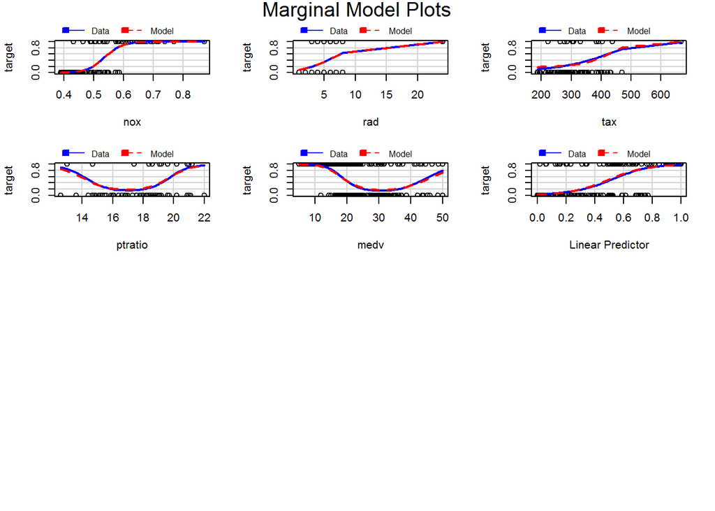

```r
# ------------------------
# marginal model plots
mmps(m.re,layout=c(4,3),key=TRUE)
```

STOP

Now run metrics

```r
# Coefficient Interpretation

# Logit model average marginal effects - use it to generate interpretable versions of coefficients
LogitScalar <- mean(dlogis(predict(m.re, type = "link")))
LogitScalar * coef(m.re)
```

```
##   (Intercept)           nox           rad          age1           tax
## -1.9302497579  2.2948192811  0.0476668470  0.0878612836 -0.0005320579
##       ptratio          medv
##  0.0252071403  0.0046855361
```

```r
# Logit model predicted probabilities - yields likelihood that each eval item is '+'
#
predprob.crime<- round(predict(m.re, type="response"), 2)
summary(predprob.crime)
```

```
##    Min. 1st Qu.  Median    Mean 3rd Qu.    Max.
##   0.000   0.020   0.510   0.499   1.000   1.000
```

```r
# Percent correctly predicted values
# NOTE: Need to create variable 'Y' for this to work - set it to response variable
Y <- hw3.re[,14]

pred.crime <- round(fitted(m.re))

table(true = Y, pred = pred.crime)
```

```
##     pred
## true   0   1
##    0 194  26
##    1  19 200
```

```r
# t.r <- data.frame(table(true = Y, pred = pred.crime))
# t.r

# now use functions built in HW 2 to get required statistics
accuracy(Y, pred.crime)
```

```
## [1] 0.8974943
```

```r
classif.err.rate(Y, pred.crime)
```

```
## [1] 0.1025057
```

```r
precision(Y, pred.crime)
```

```
## [1] 0.8849558
```

```r
sensitivity(Y, pred.crime)
```

```
## [1] 0.913242
```

```r
specificity(Y, pred.crime)
```

```
## [1] 0.8818182
```

```r
F1.Score(Y, pred.crime)
```

```
## [1] 0.8988764
```

```r
# get AUC
rocCurve <- roc(response= Y, predictor= pred.crime)
auc(rocCurve)
```

```
## Area under the curve: 0.8975
```

Summary Table:

[output not shown]

# Part 4. Select Models

```r
accuracy(hw2$class, hw2$scored.class)
classif.err.rate(hw2$class, hw2$scored.class)
precision(hw2$class, hw2$scored.class)
sensitivity(hw2$class, hw2$scored.class)
specificity(hw2$class, hw2$scored.class)
F1.Score(hw2$class, hw2$scored.class)

rocCurve <- roc(response=actual, predictor=predicted)
# r <- plot(rocCurve, legacy.axes = TRUE)
auc(rocCurve)
```